```python
import seaborn as sns
import matplotlib.pyplot as plt
import matplotlib as mpl
import pandas as pd
import numpy as np
from glob import glob
import os
import scanpy as sc,anndata as ad
import squidpy as sq
import sys
from allen_vignette_functions import *
import seaborn as sns
```

# Sketching-based evaluation of spatial transcriptomics subsampling methods

This notebook demonstrates how different sketching strategies preserve biological structure in a large MERFISH mouse brain dataset from the Allen Institute atlas. Starting from the full dataset, we generate multiple 10% sketches using **leverage score sampling**, **geometric sketching (geosketch)**, **scSampler**, and a **uniform random baseline**, with variants defined in transcriptomic, spatial, and spatially smoothed latent spaces.

We then compare these sketches to the full dataset across several downstream analyses:

- **UMAP structure** to assess preservation of transcriptomic organization,
- **spatially variable genes** using Moran’s I,
- **spatially informed ligand–receptor interactions** using **LIANA+**,
- and **spatial pathway / regulator activity** using **decoupler** together with Moran’s I.

The goal is to evaluate which sketching strategies best retain both global expression structure and spatially resolved biological signals, while substantially reducing dataset size for downstream analysis.

## Load in the dataset

Please see the "sagital_brain_preprocessing.ipynb" for instructions on how to download the data from the Allen Institute Mouse brain atlas.

```python
adata = sc.read_h5ad("/Volumes/igingerich/public_data/allen_institute_data/processed_data/merfish_sagital_brain.h5ad")
```

```python
## Convert ensemble ID to gene names:
import mygene
import pandas as pd

adata.var["ensembl_id"] = adata.var_names.str.replace(r"\.\d+$", "", regex=True)

mg = mygene.MyGeneInfo()
res = mg.querymany(
    adata.var["ensembl_id"].tolist(),
    scopes="ensembl.gene",
    fields="symbol",
    species="mouse",
    as_dataframe=True
)

res = res.reset_index().rename(columns={"query": "ensembl_id"})
res = res[["ensembl_id", "symbol"]]

adata.var = adata.var.merge(res, on="ensembl_id", how="left")
adata.var["original_ensembl"] = adata.var["ensembl_id"]
adata.var_names = adata.var["symbol"].fillna(adata.var["original_ensembl"])
adata.var_names_make_unique()
```

```
2026-04-02 11:55:03 | [WARNING] Input sequence provided is already in string format. No operation performed
2026-04-02 11:55:03 | [WARNING] Input sequence provided is already in string format. No operation performed
2026-04-02 11:55:03 | [INFO] querying 1-1000 ...
2026-04-02 11:55:05 | [INFO] HTTP Request: POST https://mygene.info/v3/query/ "HTTP/1.1 200 OK"
2026-04-02 11:55:06 | [INFO] querying 1001-1122 ...
2026-04-02 11:55:07 | [INFO] HTTP Request: POST https://mygene.info/v3/query/ "HTTP/1.1 200 OK"
2026-04-02 11:55:08 | [INFO] Finished.
2026-04-02 11:55:08 | [WARNING] 2 input query terms found no hit:	['ENSMUSG00000109473', 'ENSMUSG00000113186']
2026-04-02 11:55:08 | [INFO] Pass "returnall=True" to return complete lists of duplicate or missing query terms.
```

## Perform sketching on the data

We will now demonstrate how to use **geometric sketching** and **leverage score-based sketching** to extract a representative subset of cells for downstream analysis. These approaches are designed to retain the structure of the full dataset while substantially reducing its size.

For leverage score sampling, we include both:

- the **Seurat-style approximate leverage score approach**, based on a randomized sketched QR decomposition, and
- an **SVD-based leverage score approach**, including a spatially smoothed variant.

The Seurat implementation is especially efficient for large sparse single-cell matrices and is described in the Seurat sketching tutorial:

- Seurat sketch analysis tutorial: https://satijalab.org/seurat/articles/seurat5_sketch_analysis

For more details on the underlying randomized leverage score approximation method, see:

- Clarkson & Woodruff (2017): https://arxiv.org/pdf/1207.6365

## Add leverage scores computed in R to the object

```python
directory = "/Volumes/igingerich/public_data/allen_institute_data/processed_data"


leverage_df = pd.read_csv(
    "/Volumes/igingerich/public_data/allen_institute_data/processed_data/leverage_scores.csv"
)
#adata.obs["gene_score"] = gene_scores_df["leverage_score"].values
```

## Leverage score sampling via randomized SVD

As an alternative to the Seurat-style approximation above, we also compute leverage scores from a low-rank decomposition of the expression matrix using **randomized SVD**. This provides an efficient way to capture the dominant transcriptomic structure of the dataset without computing a full decomposition.

Cells with high leverage scores are those that contribute strongly to the low-dimensional structure of the data. Sampling cells with probability proportional to these scores enriches for transcriptomically informative and potentially rare populations, yielding a compact sketch that better preserves the diversity of the full dataset than uniform random sampling.

For methodological details on randomized SVD, see:

- Halko et al. (2011): https://epubs.siam.org/doi/10.1137/090771806

```python
from sklearn.decomposition import PCA, TruncatedSVD
from scipy.sparse.linalg import svds
from sklearn.utils.extmath import randomized_svd
```

```python
## SVD based levearge score


rank = 50
seed = 42

if type(adata.X) is not np.ndarray:
    X = adata.X.toarray()
else:
    X = adata.X.copy()
#mean center
#X_centered = X - X.mean(axis=0)
print("computing scores...")
U, S, VT = randomized_svd(X, n_components = rank, random_state = seed)


py_scores = np.array(np.sum(U**2, axis = 1))

leverage_svd_df = pd.DataFrame({'leverage_score_svd': py_scores})
```

```
computing scores...
```

## Spatially smoothed leverage scores

In our paper, we also introduce a **spatially smoothed** variant of leverage score sampling. Standard leverage scores are computed purely from transcriptomic structure, and therefore do not account for whether cells belong to spatially coherent regions in the tissue.

To address this, we smooth the low-dimensional transcriptomic representation over a spatial neighborhood graph before computing leverage scores. This increases the influence of cells that are not only transcriptomically informative, but also embedded within spatially structured local neighborhoods.

In practice, this allows the sketch to better retain regions that may be subtle in expression space alone, but are biologically meaningful because of their spatial organization.

```python
from scipy.sparse import vstack,csr_matrix,bsr_matrix,coo_matrix,issparse
from sklearn.neighbors import NearestNeighbors,BallTree
```

```python
rank = 50
seed = 42
kNN_threshold = 50
beta = 0
platform = 'merfish'


print('building weights...')
weights = build_weights_matrix(adata, n_neighbors=kNN_threshold, beta = beta, platform = platform)

#spatially smooth the pca_data
smoothed_svd = weights @ csr_matrix(U)
# Convert to dense array if needed
smoothed_svd = smoothed_svd.toarray()

py_scores_smoothed = np.array(np.sum(smoothed_svd**2, axis = 1))
smoothed_leverage_df = pd.DataFrame({'leverage_score_svd_smoothed': py_scores_smoothed})
```

```
building weights...
```

### Sampling cells using leverage scores

After computing leverage scores, we convert them into sampling probabilities and draw a fixed fraction of cells without replacement. This means that cells with higher leverage scores are more likely to be retained in the sketch.

Compared with uniform random sampling, this strategy preferentially preserves cells that are most informative for the global structure of the dataset, including rare or geometrically distinctive populations.

### Make the sketches

```python
### Add the scores to the adata object for sampling
adata.obs["gene_score"]              = leverage_df["leverage_score"].values
adata.obs["gene_score_svd"]          = leverage_svd_df["leverage_score_svd"].values
adata.obs["gene_score_svd_smoothed"] = smoothed_leverage_df["leverage_score_svd_smoothed"].values

#quick check:
assert len(leverage_df) == adata.n_obs, "Row count mismatch!"

# do the sampling
fraction = 0.10
seed     = 42

idx = leverage_index(adata, method="leverage",
                     fraction=fraction, seed=seed)
leverage_adata = adata[idx].copy()


idx = leverage_index(adata, method="leverage_svd",
                     fraction=fraction, seed=seed)
leverage_svd_adata = adata[idx].copy()


idx = leverage_index(adata, method="leverage_svd_smoothed",
                     fraction=fraction, seed=seed)
leverage_svd_smoothed_adata = adata[idx].copy()


print(f"Original:          {adata.n_obs} cells")
print(f"Leverage:          {leverage_adata.n_obs} cells")
print(f"Leverage SVD:      {leverage_svd_adata.n_obs} cells")
print(f"Leverage smoothed: {leverage_svd_smoothed_adata.n_obs} cells")
```

```
Original:          81452 cells
Leverage:          8145 cells
Leverage SVD:      8145 cells
Leverage smoothed: 8145 cells
```

## Geometric sketching useing geoSketch and scSampler

In addition to leverage score-based sampling, we apply two geometry-based sketching methods: **geosketch** and **scSampler**. Both methods aim to select a subset of cells that uniformly covers the transcriptomic manifold, rather than sampling proportional to density — meaning rare populations are preserved even if they are underrepresented in the full dataset.

For each method we generate three variants of the sketch, using different input spaces:

- **Transcriptomic space**: the top PCA components of the expression matrix (`X_pca`)
- **Coordinate space**: raw spatial $(x, y)$ coordinates, capturing physical tissue structure
- **Spatially smoothed PCA space**: PCA components smoothed over the spatial neighborhood graph, which integrates both transcriptomic and spatial structure

```python
from geosketch import gs
from scsampler import scsampler

def _sample_size(n_obs: int, fraction: float) -> int:
    """Convert a fraction into an integer sample size (at least 1, at most n_obs)."""
    if not (0 < fraction <= 1):
        raise ValueError(f"`fraction` must be in (0, 1], got {fraction}")
    return max(1, min(n_obs, int(round(n_obs * fraction))))
```

```python
fraction      = 0.10
seed          = 42
kNN_threshold = 50
beta          = 0
platform      = 'merfish'

n = adata.n_obs
k = _sample_size(n, fraction)

# Pre-compute spatially smoothed PCA (shared across geo and scSampler)
weights      = build_weights_matrix(adata, n_neighbors=kNN_threshold, beta=beta, platform=platform)
smoothed_pca = (weights @ csr_matrix(adata.obsm["X_pca"])).toarray()

# ── Geosketch ──────────────────────────────────────────────────────────────
geo_transcriptomic_index = sorted(gs(adata.obsm["X_pca"],    k, seed=seed, replace=False))
geo_coordinate_index     = sorted(gs(adata.obsm["spatial"],  k, seed=seed, replace=False))
geo_smoothed_index       = sorted(gs(smoothed_pca,           k, seed=seed, replace=False))

# ── scSampler ──────────────────────────────────────────────────────────────
def _scsampler_index(space, fraction, seed, random_split=16):
    idx = scsampler(space, fraction=fraction, random_state=seed,
                    copy=True, random_split=random_split)
    return sorted(list(idx[1]))

scsampler_transcriptomic_index = _scsampler_index(adata.obsm["X_pca"],   fraction, seed)
scsampler_coordinate_index     = _scsampler_index(adata.obsm["spatial"], fraction, seed)
scsampler_smoothed_index       = _scsampler_index(smoothed_pca, fraction, seed)

# ── Generate subsets ───────────────────────────────────────────────────────
geo_transcriptomic_adata    = adata[geo_transcriptomic_index].copy()
geo_coordinate_adata        = adata[geo_coordinate_index].copy()
geo_smoothed_adata          = adata[geo_smoothed_index].copy()

scsampler_transcriptomic_adata = adata[scsampler_transcriptomic_index].copy()
scsampler_coordinate_adata     = adata[scsampler_coordinate_index].copy()
scsampler_smoothed_adata       = adata[scsampler_smoothed_index].copy()


## We also need to include a Uniform random sample for comparision


rng = np.random.default_rng(seed)
random_inx = sorted(rng.choice(n, size=k, replace=False).tolist())

uniform_adata = adata[random_inx].copy()


# ── Collect all sketches for downstream looping ────────────────────────────
sketches = [
    ("leverage",                leverage_adata),
    ("leverage_svd",            leverage_svd_adata),
    ("leverage_svd_smoothed",   leverage_svd_smoothed_adata),
    ("geo_transcriptomic",      geo_transcriptomic_adata),
    ("geo_coordinate",          geo_coordinate_adata),
    ("geo_smoothed",            geo_smoothed_adata),
    ("scsampler_transcriptomic", scsampler_transcriptomic_adata),
    ("scsampler_coordinate",    scsampler_coordinate_adata),
    ("scsampler_smoothed",      scsampler_smoothed_adata),
    ('uniform',                 uniform_adata),
]

print(f"Original: {adata.n_obs} cells")
for name, sketch in sketches:
    print(f"  {name:<30} {sketch.n_obs} cells")
```

```
Original: 81452 cells
  leverage                       8145 cells
  leverage_svd                   8145 cells
  leverage_svd_smoothed          8145 cells
  geo_transcriptomic             8145 cells
  geo_coordinate                 8145 cells
  geo_smoothed                   8145 cells
  scsampler_transcriptomic       8145 cells
  scsampler_coordinate           8145 cells
  scsampler_smoothed             8145 cells
  uniform                        8145 cells
```

## Examine the sketches

- UMAP projections
- Spatially varible genes
- Local bivariate anaylsis
- Spatial pathway anaylsis

## UMAPs

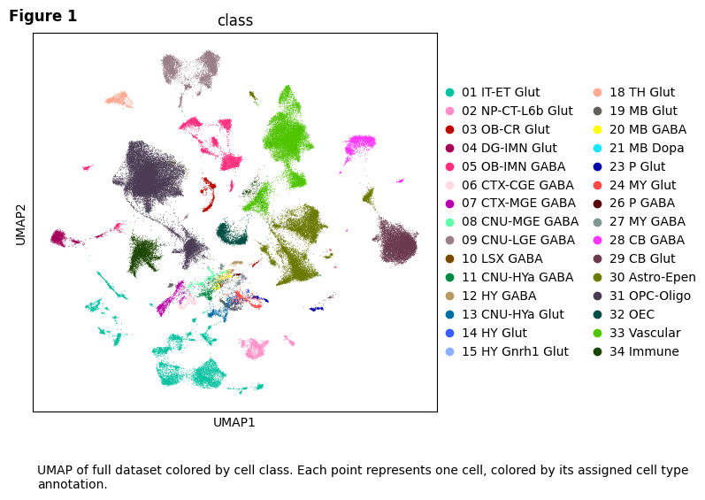

```python
import matplotlib.pyplot as plt

fig, ax = plt.subplots(figsize=(8, 5))

sc.pl.umap(adata, color='class', show=False, ax=ax)

# Add figure label
fig.text(
    0.01, 0.98,
    "Figure 1",
    fontsize=12,
    fontweight="bold",
    va="top",
    ha="left",
    transform=fig.transFigure,
)

# Add figure caption
fig.text(
    0.05, -0.05,
    "UMAP of full dataset colored by cell class. "
    "Each point represents one cell, colored by its assigned cell type annotation.",
    fontsize=10,
    va="top",
    ha="left",
    wrap=True,
    transform=fig.transFigure,
)

plt.tight_layout()
plt.show()
```

```python
## Note: the following WARNING: adata.X seems to be already log-transformed is a false positive, ignore.
```

```
Computing UMAP for: leverage
WARNING: adata.X seems to be already log-transformed.
```

```
... storing 'symbol' as categorical
```

```
Computing UMAP for: leverage_svd
WARNING: adata.X seems to be already log-transformed.
```

```
... storing 'symbol' as categorical
```

```
Computing UMAP for: leverage_svd_smoothed
WARNING: adata.X seems to be already log-transformed.
```

```
... storing 'symbol' as categorical
```

```
Computing UMAP for: geo_transcriptomic
WARNING: adata.X seems to be already log-transformed.
```

```
... storing 'symbol' as categorical
```

```
Computing UMAP for: geo_coordinate
WARNING: adata.X seems to be already log-transformed.
```

```
... storing 'symbol' as categorical
```

```
Computing UMAP for: geo_smoothed
WARNING: adata.X seems to be already log-transformed.
```

```
... storing 'symbol' as categorical
```

```
Computing UMAP for: scsampler_transcriptomic
WARNING: adata.X seems to be already log-transformed.
```

```
... storing 'symbol' as categorical
```

```
Computing UMAP for: scsampler_coordinate
WARNING: adata.X seems to be already log-transformed.
```

```
... storing 'symbol' as categorical
```

```
Computing UMAP for: scsampler_smoothed
WARNING: adata.X seems to be already log-transformed.
```

```
... storing 'symbol' as categorical
```

```
Computing UMAP for: uniform
WARNING: adata.X seems to be already log-transformed.
```

```
... storing 'symbol' as categorical
```

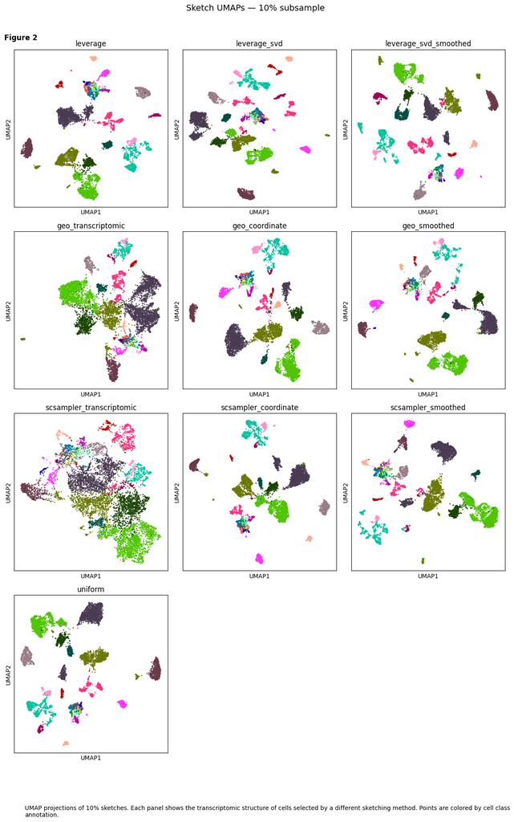

```python
import math
import os
os.chdir(os.path.expanduser("~"))  # switch cwd to home directory

fig = plot_sketch_umaps(
    sketches,
    color="class",
    ncols=3,
    figsize_per_panel=(4, 4),
    fraction=0.10,
    fig_label="Figure 2",
    fig_caption="UMAP projections of 10% sketches. "
                "Each panel shows the transcriptomic structure of cells selected by a different sketching method. "
                "Points are colored by cell class annotation.",
    save=None,
)
```